# Airline Route Profitability

DATA 2401

Niyog Uprety & Shaheer Ahmed

April 2026

# About the Dataset

- **Source:** Kaggle, Airline Route Profitability Dataset by Muhammad Waleed
- **Context:** Simulated full-year financial data for a major Middle Eastern airline based in **Dubai (DXB)**
- **Size:** 7,974 flights across multiple routes, seasons, and aircraft types
- **Goal:** Find what actually drives airline profitability
- **Key metrics:** We use both **Profit** and **Profit Margin**, since raw profit alone can be misleading

# Route Network and Fleet

- **Short-Haul (1 to 3.5 hrs):** DOH, MCT, KWI, BAH, RUH, JED, CAI, AMM
- **Medium-Haul (2.5 to 7 hrs):** BOM, DEL, IST, LHR, BLR, HYD, MAA, KHI, LHE, CMB
- **Long-Haul (6.5 to 16.5 hrs):** JFK, SYD, MEL, SIN, HKG, BKK, KUL, CDG, FRA, LAX, SFO, ORD
- **Aircraft types:** Boeing 737-800, Airbus A320, Boeing 777-300ER, Airbus A380, Boeing 787-9, Airbus A350-900

A Dubai-based carrier operates both regional and intercontinental flights, so profitability depends on both **route scale** and **operating efficiency**.

# Data Cleaning

- Checked for missing values across all 33 columns
- Replaced missing numeric values with the **median**
- Replaced missing text values with **“Unknown”**
- Converted Flight_Date into proper date format
- Dataset was fairly clean with no major issues found

```
## Missing values after cleaning: 0
```

# Key Variables in the Analysis

- **Profit:** Total earnings after costs
- **Profit_Margin:** Profit as a percentage of revenue
- **Load_Factor:** How full the flight was
- **Route_Category:** Short-haul, medium-haul, or long-haul
- **Season:** Peak, Shoulder, Normal, or Low
- **Demand_Level:** High or Medium demand
- **Flight_Date:** Used for monthly trend analysis

These variables help compare both **how much money flights make** and **how efficiently they make it**.

# Correct Season Definitions

- **Peak:** January to February and December
- **Shoulder:** March to April and October to November
- **Normal:** May and September
- **Low:** June to August

This is important because it means **winter months are Peak** and **summer months are Low**, which explains the monthly profit trend later.

# How Does Profit Spread Across Flights?

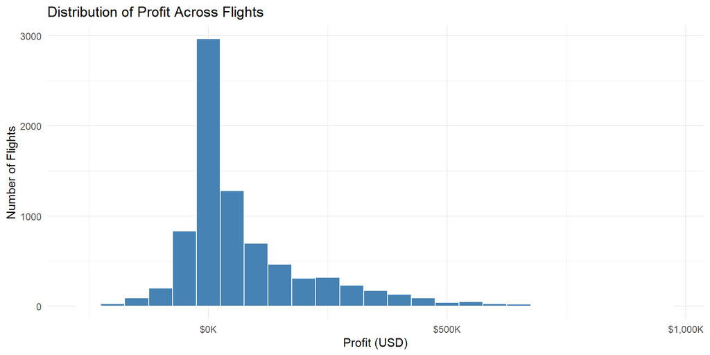

Most flights earn between **$0 and $500K**. Some operate at a loss, while a smaller number earn much more than the rest.

# Are Long-Haul Routes More Profitable?

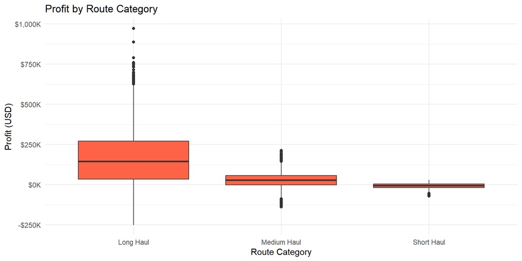

Long-haul routes generally earn the **highest total profit**, while short-haul routes perform the weakest.